# Is Lewis Hamilton the greatest Formula 1 driver?

###### By Aryan Agarwal

In this project, I am going to be using the public database that contains information about Formula 1 including the drivers and races going back to 1950. Lewis Hamilton is one of the best drivers ever in motorsport having won the drivers championship a record 7 times with a 8th one almost achieved this year. Many at times drivers are compared to one another such as the great Michael Schumacher who also has 7 World Championship Titles. Lewis Hamilton has been beating every record set by Michael Schumacher including highest number of wins, highest number of pole positions, etc. I will be looking at data to analyze how much better is he as compared to other drivers and decided to form my own opinion on the debate between Michael Schumacher and Lewis Hamilton to see who is the greatest.

### Data Scraping

I import all the libraries that I will need in order to compute data analysis on my data. I got this data from the link given in the final project description which is called "Awesome Public Datasets". I found a database linked on that page made by Ergast which included information about Formula 1. I downloaded the database as csv files and uploaded them to jupyter which I will import using pandas below.

```python
import numpy as np
import pandas as pd
import matplotlib.pyplot as plt
import seaborn as sns
import sklearn
from sklearn.linear_model import LinearRegression
from sklearn.preprocessing import RobustScaler
from sklearn.preprocessing import LabelEncoder
from sklearn.model_selection import train_test_split
from sklearn.metrics import mean_squared_error
from sklearn.tree import DecisionTreeRegressor
```

```python
df = pd.read_csv("./data/drivers.csv")
df.head()
```

|  | driverId | driverRef | number | code | forename | surname | dob | nationality | url |
| --- | --- | --- | --- | --- | --- | --- | --- | --- | --- |
| 0 | 1 | hamilton | 44 | HAM | Lewis | Hamilton | 1/7/1985 | British | http://en.wikipedia.org/wiki/Lewis_Hamilton |
| 1 | 2 | heidfeld | \N | HEI | Nick | Heidfeld | 5/10/1977 | German | http://en.wikipedia.org/wiki/Nick_Heidfeld |
| 2 | 3 | rosberg | 6 | ROS | Nico | Rosberg | 6/27/1985 | German | http://en.wikipedia.org/wiki/Nico_Rosberg |
| 3 | 4 | alonso | 14 | ALO | Fernando | Alonso | 7/29/1981 | Spanish | http://en.wikipedia.org/wiki/Fernando_Alonso |
| 4 | 5 | kovalainen | \N | KOV | Heikki | Kovalainen | 10/19/1981 | Finnish | http://en.wikipedia.org/wiki/Heikki_Kovalainen |

```python
df2 = pd.read_csv("./data/results.csv")
df2.head()
```

|  | resultId | raceId | driverId | constructorId | number | grid | position | positionText | positionOrder | points | laps | time | milliseconds | fastestLap | rank | fastestLapTime | fastestLapSpeed | statusId |
| --- | --- | --- | --- | --- | --- | --- | --- | --- | --- | --- | --- | --- | --- | --- | --- | --- | --- | --- |
| 0 | 1 | 18 | 1 | 1 | 22 | 1 | 1 | 1 | 1 | 10.0 | 58 | 1:34:50.616 | 5690616 | 39 | 2 | 1:27.452 | 218.300 | 1 |
| 1 | 2 | 18 | 2 | 2 | 3 | 5 | 2 | 2 | 2 | 8.0 | 58 | +5.478 | 5696094 | 41 | 3 | 1:27.739 | 217.586 | 1 |
| 2 | 3 | 18 | 3 | 3 | 7 | 7 | 3 | 3 | 3 | 6.0 | 58 | +8.163 | 5698779 | 41 | 5 | 1:28.090 | 216.719 | 1 |
| 3 | 4 | 18 | 4 | 4 | 5 | 11 | 4 | 4 | 4 | 5.0 | 58 | +17.181 | 5707797 | 58 | 7 | 1:28.603 | 215.464 | 1 |
| 4 | 5 | 18 | 5 | 1 | 23 | 3 | 5 | 5 | 5 | 4.0 | 58 | +18.014 | 5708630 | 43 | 1 | 1:27.418 | 218.385 | 1 |

```python
df3 = df.merge(df2,on=["driverId"])
df3 = df3.drop(['url'],axis = 1)
```

Now I filter out the data from the above joined dataframe to extract data for Lewis Hamilton and Michael Schumacher in separate dataframes to make it easier to compare their stats.

```python
# Extracting information for Hamilton
df4 = pd.DataFrame()
for iter,row in df3.iterrows():
    if row['code'] == 'HAM':
        df4 = df4.append(row)
df4
```

|  | code | constructorId | dob | driverId | driverRef | fastestLap | fastestLapSpeed | fastestLapTime | forename | grid | ... | points | position | positionOrder | positionText | raceId | rank | resultId | statusId | surname | time |
| --- | --- | --- | --- | --- | --- | --- | --- | --- | --- | --- | --- | --- | --- | --- | --- | --- | --- | --- | --- | --- | --- |
| 0 | HAM | 1.0 | 1/7/1985 | 1.0 | hamilton | 39 | 218.300 | 1:27.452 | Lewis | 1.0 | ... | 10.0 | 1 | 1.0 | 1 | 18.0 | 2 | 1.0 | 1.0 | Hamilton | 1:34:50.616 |
| 1 | HAM | 1.0 | 1/7/1985 | 1.0 | hamilton | 53 | 209.033 | 1:35.462 | Lewis | 9.0 | ... | 4.0 | 5 | 5.0 | 5 | 19.0 | 3 | 27.0 | 1.0 | Hamilton | +46.548 |
| 2 | HAM | 1.0 | 1/7/1985 | 1.0 | hamilton | 25 | 203.969 | 1:35.520 | Lewis | 3.0 | ... | 0.0 | 13 | 13.0 | 13 | 20.0 | 19 | 57.0 | 11.0 | Hamilton | \N |
| 3 | HAM | 1.0 | 1/7/1985 | 1.0 | hamilton | 20 | 204.323 | 1:22.017 | Lewis | 5.0 | ... | 6.0 | 3 | 3.0 | 3 | 21.0 | 3 | 69.0 | 1.0 | Hamilton | +4.187 |
| 4 | HAM | 1.0 | 1/7/1985 | 1.0 | hamilton | 31 | 222.085 | 1:26.529 | Lewis | 3.0 | ... | 8.0 | 2 | 2.0 | 2 | 22.0 | 2 | 90.0 | 1.0 | Hamilton | +3.779 |
| ... | ... | ... | ... | ... | ... | ... | ... | ... | ... | ... | ... | ... | ... | ... | ... | ... | ... | ... | ... | ... | ... |
| 265 | HAM | 131.0 | 1/7/1985 | 1.0 | hamilton | 37 | 197.144 | 1:41.420 | Lewis | 3.0 | ... | 15.0 | 3 | 3.0 | 3 | 1047.0 | 5 | 24948.0 | 1.0 | Hamilton | +18.415 |
| 266 | HAM | 131.0 | 1/7/1985 | 1.0 | hamilton | 44 | 207.235 | 1:34.015 | Lewis | 2.0 | ... | 25.0 | 1 | 1.0 | 1 | 1052.0 | 4 | 24966.0 | 1.0 | Hamilton | 1:32:03.897 |
| 267 | HAM | 131.0 | 1/7/1985 | 1.0 | hamilton | 60 | 230.403 | 1:16.702 | Lewis | 1.0 | ... | 19.0 | 2 | 2.0 | 2 | 1053.0 | 1 | 24987.0 | 1.0 | Hamilton | +22.000 |
| 268 | HAM | 131.0 | 1/7/1985 | 1.0 | hamilton | 47 | 206.971 | 1:20.933 | Lewis | 2.0 | ... | 25.0 | 1 | 1.0 | 1 | 1054.0 | 4 | 25006.0 | 1.0 | Hamilton | 1:34:31.421 |
| 269 | HAM | 131.0 | 1/7/1985 | 1.0 | hamilton | 54 | 208.640 | 1:20.665 | Lewis | 1.0 | ... | 25.0 | 1 | 1.0 | 1 | 1055.0 | 5 | 25026.0 | 1.0 | Hamilton | 1:33:07.680 |

270 rows × 25 columns

```python
# Extracting information about Schumacher
df5 = pd.DataFrame()
for iter,row in df3.iterrows():
    if row['driverId'] == 30:
        df5 = df5.append(row)
df5
```

|  | code | constructorId | dob | driverId | driverRef | fastestLap | fastestLapSpeed | fastestLapTime | forename | grid | ... | points | position | positionOrder | positionText | raceId | rank | resultId | statusId | surname | time |
| --- | --- | --- | --- | --- | --- | --- | --- | --- | --- | --- | --- | --- | --- | --- | --- | --- | --- | --- | --- | --- | --- |
| 4497 | MSC | 6.0 | 1/3/1969 | 30.0 | michael_schumacher | 38 | 210.576 | 1:32.523 | Michael | 1.0 | ... | 8.0 | 2 | 2.0 | 2 | 53.0 | 2 | 744.0 | 1.0 | Schumacher | +1.246 |
| 4498 | MSC | 6.0 | 1/3/1969 | 30.0 | michael_schumacher | 44 | 208.629 | 1:35.647 | Michael | 14.0 | ... | 3.0 | 6 | 6.0 | 6 | 54.0 | 5 | 770.0 | 1.0 | Schumacher | +43.854 |
| 4499 | MSC | 6.0 | 1/3/1969 | 30.0 | michael_schumacher | 27 | 218.981 | 1:27.180 | Michael | 10.0 | ... | 0.0 | \N | 17.0 | R | 55.0 | 3 | 803.0 | 3.0 | Schumacher | \N |
| 4500 | MSC | 6.0 | 1/3/1969 | 30.0 | michael_schumacher | 19 | 210.961 | 1:24.624 | Michael | 1.0 | ... | 10.0 | 1 | 1.0 | 1 | 56.0 | 2 | 809.0 | 1.0 | Schumacher | 1:31:06.486 |
| 4501 | MSC | 6.0 | 1/3/1969 | 30.0 | michael_schumacher | 39 | 201.226 | 1:32.099 | Michael | 2.0 | ... | 10.0 | 1 | 1.0 | 1 | 57.0 | 1 | 831.0 | 1.0 | Schumacher | 1:35:58.765 |
| ... | ... | ... | ... | ... | ... | ... | ... | ... | ... | ... | ... | ... | ... | ... | ... | ... | ... | ... | ... | ... | ... |
| 4800 | MSC | 131.0 | 1/3/1969 | 30.0 | michael_schumacher | 49 | 195.902 | 1:43.184 | Michael | 10.0 | ... | 0.0 | 13 | 13.0 | 13 | 875.0 | 13 | 21604.0 | 1.0 | Schumacher | +89.241 |
| 4801 | MSC | 131.0 | 1/3/1969 | 30.0 | michael_schumacher | 53 | 206.769 | 1:29.230 | Michael | 14.0 | ... | 0.0 | 22 | 22.0 | 22 | 876.0 | 9 | 21637.0 | 31.0 | Schumacher | \N |
| 4802 | MSC | 131.0 | 1/3/1969 | 30.0 | michael_schumacher | 51 | 190.015 | 1:45.225 | Michael | 13.0 | ... | 0.0 | 11 | 11.0 | 11 | 877.0 | 6 | 21650.0 | 1.0 | Schumacher | +28.075 |
| 4803 | MSC | 131.0 | 1/3/1969 | 30.0 | michael_schumacher | 54 | 196.652 | 1:40.923 | Michael | 5.0 | ... | 0.0 | 16 | 16.0 | 16 | 878.0 | 15 | 21679.0 | 11.0 | Schumacher | \N |
| 4804 | MSC | 131.0 | 1/3/1969 | 30.0 | michael_schumacher | 37 | 193.522 | 1:20.158 | Michael | 13.0 | ... | 6.0 | 7 | 7.0 | 7 | 879.0 | 15 | 21694.0 | 1.0 | Schumacher | +11.907 |

308 rows × 25 columns

Now that I have the information for each driver, I combine this data with the race results for each of their races based on the raceID that they took part in. Since both drivers ruled the sport during different eras, it is difficult to make direct comparisons as rules change such as the point system which was 10 points for the winner prior to 2010 and was changed to 25 points for race winner since then. I have also deleted a lot of the columns that I would not be using as it makes it harder to understand the dataframe and it would not fit within browser window.

```python
# Merging with data for Hamilton for each race and removing unnecessary columns not needed
df = pd.read_csv("./data/races.csv")
df4 = df4.merge(df,on=["raceId"])
df4 = df4.drop(['dob', 'milliseconds', 'url', 'time_y', 'time_x', 'driverRef', 'nationality', 'driverId', 'constructorId',
                'fastestLap', 'fastestLapSpeed', 'fastestLapTime', 'laps', 'number_y', 'positionOrder', 'rank'
                ,'statusId', 'number_x', 'resultId', 'circuitId', 'code', 'positionText', 'date'], axis = 1)
df4
```

|  | forename | grid | points | position | raceId | surname | year | round | name |
| --- | --- | --- | --- | --- | --- | --- | --- | --- | --- |
| 0 | Lewis | 1.0 | 10.0 | 1 | 18.0 | Hamilton | 2008 | 1 | Australian Grand Prix |
| 1 | Lewis | 9.0 | 4.0 | 5 | 19.0 | Hamilton | 2008 | 2 | Malaysian Grand Prix |
| 2 | Lewis | 3.0 | 0.0 | 13 | 20.0 | Hamilton | 2008 | 3 | Bahrain Grand Prix |
| 3 | Lewis | 5.0 | 6.0 | 3 | 21.0 | Hamilton | 2008 | 4 | Spanish Grand Prix |
| 4 | Lewis | 3.0 | 8.0 | 2 | 22.0 | Hamilton | 2008 | 5 | Turkish Grand Prix |
| ... | ... | ... | ... | ... | ... | ... | ... | ... | ... |
| 265 | Lewis | 3.0 | 15.0 | 3 | 1047.0 | Hamilton | 2020 | 17 | Abu Dhabi Grand Prix |
| 266 | Lewis | 2.0 | 25.0 | 1 | 1052.0 | Hamilton | 2021 | 1 | Bahrain Grand Prix |
| 267 | Lewis | 1.0 | 19.0 | 2 | 1053.0 | Hamilton | 2021 | 2 | Emilia Romagna Grand Prix |
| 268 | Lewis | 2.0 | 25.0 | 1 | 1054.0 | Hamilton | 2021 | 3 | Portuguese Grand Prix |
| 269 | Lewis | 1.0 | 25.0 | 1 | 1055.0 | Hamilton | 2021 | 4 | Spanish Grand Prix |

270 rows × 9 columns

```python
# Doing the same for Schumacher
df = pd.read_csv("./data/races.csv")
df5 = df5.merge(df,on=["raceId"])
df5 = df5.drop(['dob', 'milliseconds', 'url', 'time_y', 'time_x', 'driverRef', 'nationality', 'driverId', 'constructorId',
                'fastestLap', 'fastestLapSpeed', 'fastestLapTime', 'laps', 'number_y', 'positionOrder', 'rank'
                ,'statusId', 'number_x', 'resultId', 'circuitId', 'code', 'positionText', 'date'], axis = 1)
df5
```

|  | forename | grid | points | position | raceId | surname | year | round | name |
| --- | --- | --- | --- | --- | --- | --- | --- | --- | --- |
| 0 | Michael | 1.0 | 8.0 | 2 | 53.0 | Schumacher | 2006 | 1 | Bahrain Grand Prix |
| 1 | Michael | 14.0 | 3.0 | 6 | 54.0 | Schumacher | 2006 | 2 | Malaysian Grand Prix |
| 2 | Michael | 10.0 | 0.0 | \N | 55.0 | Schumacher | 2006 | 3 | Australian Grand Prix |
| 3 | Michael | 1.0 | 10.0 | 1 | 56.0 | Schumacher | 2006 | 4 | San Marino Grand Prix |
| 4 | Michael | 2.0 | 10.0 | 1 | 57.0 | Schumacher | 2006 | 5 | European Grand Prix |
| ... | ... | ... | ... | ... | ... | ... | ... | ... | ... |
| 303 | Michael | 10.0 | 0.0 | 13 | 875.0 | Schumacher | 2012 | 16 | Korean Grand Prix |
| 304 | Michael | 14.0 | 0.0 | 22 | 876.0 | Schumacher | 2012 | 17 | Indian Grand Prix |
| 305 | Michael | 13.0 | 0.0 | 11 | 877.0 | Schumacher | 2012 | 18 | Abu Dhabi Grand Prix |
| 306 | Michael | 5.0 | 0.0 | 16 | 878.0 | Schumacher | 2012 | 19 | United States Grand Prix |
| 307 | Michael | 13.0 | 6.0 | 7 | 879.0 | Schumacher | 2012 | 20 | Brazilian Grand Prix |

308 rows × 9 columns

```python
# Tidying up the data by repalcing new line and retired races with a 0 as well as making position numeric
df4 = df4.replace(regex=r'\\N', value=0)
df4 = df4.replace(regex=r'R', value='0')
df4['position'] = pd.to_numeric(df4['position'])

df5 = df5.replace(regex=r'\\N', value=0)
df5 = df5.replace(regex=r'R', value='0')
df5['position'] = pd.to_numeric(df5['position'])
```

### Data Visualization

Now I will use the dataframes I have created above to find patterns and try to visualize which driver is better based on some numerical value such as wins per season, average positions achieved per season, etc.

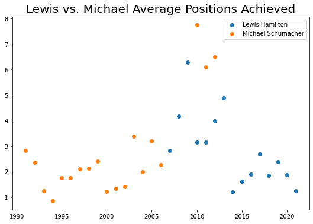

```python
tmp = df4[['position', 'year']].copy()
tmp = tmp.groupby('year').mean()

tmp2 = df5[['position', 'year']].copy()
tmp2 = tmp2.groupby('year').mean()

year = df4['year'].unique()
year2 = df5['year'].unique()
year.sort()
year2.sort()
plt.figure(figsize=(9,6))
plt.title('Lewis vs. Michael Average Positions Achieved', fontsize=20)
plt.scatter(year, tmp['position'])
plt.scatter(year2, tmp2['position'])
plt.legend(["Lewis Hamilton", 'Michael Schumacher'])
plt.show()
```

The above graph shows that the average positions achieved by Michael Schumacher was better than that achieved by Lewis Hamilton. Cross referencing this data with the years in which both drivers achieved world championships, Michael Schumacher was able to attain a better average position even without winning the championship whereas Lewis Hamilton has only been able to do so since 2014 when he switched to a new team.

```python
lew_wins = {}
for iter, row in df4.iterrows():
    if (row['position'] == 1):
        if (row['year'] in lew_wins):
            lew_wins[row['year']][0] += 1
            lew_wins[row['year']][1] += 1
        else:
            lew_wins[row['year']] = [0,0]
            lew_wins[row['year']][0] = 1
            lew_wins[row['year']][1] = 1
    else:
        if (row['year'] in lew_wins):
            lew_wins[row['year']][1] += 1
        else:
            lew_wins[row['year']] = [0,0]
            lew_wins[row['year']][1] = 1


mich_wins = {}
for iter, row in df5.iterrows():
    if (row['position'] == 1):
        if (row['year'] in mich_wins):
            mich_wins[row['year']][0] += 1
            mich_wins[row['year']][1] += 1
        else:
            mich_wins[row['year']] = [0,0]
            mich_wins[row['year']][0] = 1
            mich_wins[row['year']][1] = 1
    else:
        if (row['year'] in mich_wins):
            mich_wins[row['year']][1] += 1
        else:
            mich_wins[row['year']] = [0,0]
            mich_wins[row['year']][1] = 1
```

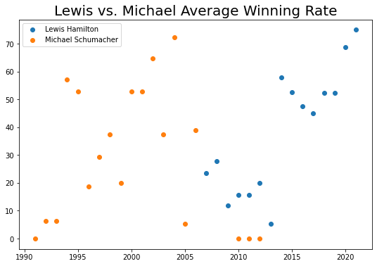

```python
year = lew_wins.keys()
year2 = mich_wins.keys()
sorted(year2)
lew_avg = []
for i in lew_wins:
    lew_avg.append((lew_wins[i][0]/lew_wins[i][1])*100)

mich_avg = []
for i in mich_wins:
    mich_avg.append((mich_wins[i][0]/mich_wins[i][1])*100)

plt.figure(figsize=(9,6))
plt.title('Lewis vs. Michael Average Winning Rate', fontsize=20)
plt.scatter(year, lew_avg)
plt.scatter(year2, mich_avg)
plt.legend(["Lewis Hamilton", 'Michael Schumacher'])
plt.show()
```

This graph shows that Lewis Hamilton has been able to achieve more wins than Michael Schumacher despite both having the same number of World Championship Titles. This can be interpreted in multiple ways depending on the bias of the person. One person can say that Michael Schumacher is better as he was able to achieve less race wins and still win the world title whereas Lewis Hamilton has only been able to do so because the team is better than the rest of the grid. Another person could say that Lewis Hamilton is much better which is why he has more wins and world titles to his name.

### Machine Learning Algorithm

```python
categories = ['forename', 'surname', 'name']
label = sklearn.preprocessing.LabelEncoder()

for i in categories:
    df4[i] = label.fit_transform(df4[i])

numerical = ['grid', 'points', 'position', 'raceId', 'year', 'round']

# Preprocessing the data
rc = RobustScaler()
df4[numerical] = rc.fit_transform(df4[numerical])
```

```python
Y = df4['points']
X = df4.drop('points', axis = 1)
```

```python
X_train, X_test, y_train, y_test = train_test_split(X, Y, test_size = 0.2, random_state = 12)
X_train.shape, X_test.shape
```

```
((216, 8), (54, 8))
```

```python
lr = LinearRegression()
lr.fit(X_train, y_train)

#predicting the target value from the model for the samples
y_test_lr = lr.predict(X_test)
y_train_lr = lr.predict(X_train)

#computing the accuracy of the model performance
acc_train_lr = lr.score(X_train, y_train)
acc_test_lr = lr.score(X_test, y_test)

#computing root mean squared error (RMSE)
rmse_train_lr = np.sqrt(mean_squared_error(y_train, y_train_lr))
rmse_test_lr = np.sqrt(mean_squared_error(y_test, y_test_lr))
print("Linear Regression: Accuracy on training Data: {:.3f}".format(acc_train_lr))
print("Linear Regression: Accuracy on test Data: {:.3f}".format(acc_test_lr))
print('\nLinear Regression: The RMSE of the training set is:', rmse_train_lr)
print('Linear Regression: The RMSE of the testing set is:', rmse_test_lr)
```

```
Linear Regression: Accuracy on training Data: 0.487
Linear Regression: Accuracy on test Data: 0.471

Linear Regression: The RMSE of the training set is: 0.3517963334043972
Linear Regression: The RMSE of the testing set is: 0.36532831451500464
```

Our linear regression does not seem to be working at its best as our accuracy for both training and testing data is only around 50 per cent. Our root mean squared error is also not very good. Now I wil try with decision tree to see if i can get better results than linear regression

```python
# instantiate the model
tree = DecisionTreeRegressor(max_depth=9)
# fit the model
tree.fit(X_train, y_train)

#predicting the target value from the model for the samples
y_test_tree = tree.predict(X_test)
y_train_tree = tree.predict(X_train)

#computing the accuracy of the model performance
acc_train_tree = tree.score(X_train, y_train)
acc_test_tree = tree.score(X_test, y_test)

#computing root mean squared error (RMSE)
rmse_train_tree = np.sqrt(mean_squared_error(y_train, y_train_tree))
rmse_test_tree = np.sqrt(mean_squared_error(y_test, y_test_tree))

print("Decision Tree: Accuracy on training Data: {:.3f}".format(acc_train_tree))
print("Decision Tree: Accuracy on test Data: {:.3f}".format(acc_test_tree))
print('\nDecision Tree: The RMSE of the training set is:', rmse_train_tree)
print('Decision Tree: The RMSE of the testing set is:', rmse_test_tree)
```

```
Decision Tree: Accuracy on training Data: 1.000
Decision Tree: Accuracy on test Data: 0.862

Decision Tree: The RMSE of the training set is: 1.9348885806869458e-16
Decision Tree: The RMSE of the testing set is: 0.1869059276549343
```

### Conclusion

In this tutorial, I compared data between Lewis Hamilton and Michael Schumacher to understand who is better solely based on numerical data. In the real world, we know this will not be applicable as there are many factors that come into play such as sporting regulation changes, performance of the team as a whole which makes it difficult to compare drivers solely based on their numerical data results. Although, one statistic that can be used is how many positions was the driver able to from the start of the race which can be diffcult for a team who is last in the standings as their car is the worst as compared to others but it is one area where the sole ability of the driver comes into play between almost equal cars. The data visualization can be used to support claims that Michael Schumacher is the greatest driver in the sport or that Lewis Hamilton is the better depending on individual bias. Here we saw that Lewis Hamilton has been able to achieve more wins on average per season but Michael Schumacher was able to get higher positions on average despite not winning as many races as Lewis Hamilton.

#### Additional resources

Some of the resources I found useful were:

- https://en.wikipedia.org/wiki/Formula_One -> This helped me in understanding how the sport works for a person not too familiar with it
- http://ergast.com/mrd/db/ -> This is the API i used to gather all the data that has been used here. Credit goes to creator.
- https://en.wikipedia.org/wiki/Michael_Schumacher -> To understand the achievements of the driver
- https://en.wikipedia.org/wiki/Lewis_Hamilton -> To understand lewis hamilton's achievements